# Practical Machine Learning Week 4 Project

A K M Anisur Rahman

## Background:

Fitness devices like Jawbone Up, Nike FuelBand, and Fitbit enable to collect large amount personal activity data relatively inexpensively. In this project, data from accelerometers on the belt, forearm, arm, and dumbell of 6 participants will be used. Six male young health participants performed one set of 10 repetitions of the Unilateral Dumbbell Biceps Curl in five different fashions [outcome variable in the model]: exactly according to the specification (Class A), throwing the elbows to the front (Class B), lifting the dumbbell only halfway (Class C), lowering the dumbbell only halfway (Class D) and throwing the hips to the front (Class E). The purpose of this project is to select and build an optimal machine learning model to predict 20 test cases.

## Setting Working directory and loading required packages

```r
setwd("C:/Users/Medicine/Desktop/Practical Machine Learning")
suppressWarnings(suppressMessages(library(caret)))
suppressWarnings(suppressMessages(library(kernlab)))
suppressWarnings(suppressMessages(library(dplyr)))
suppressWarnings(suppressMessages(library(RANN)))
suppressWarnings(suppressMessages(library(rattle)))
suppressWarnings(suppressMessages(library(rpart)))
suppressWarnings(suppressMessages(library(randomForest)))
suppressWarnings(suppressMessages(library(gbm)))
suppressWarnings(suppressMessages(library(rpart.plot)))
suppressWarnings(suppressMessages(library(RColorBrewer)))
```

## Downloading and reading raw data

```r
urltrain <- "http://d396qusza40orc.cloudfront.net/predmachlearn/pml-training.csv"
download.file(urltrain, destfile="pml-training.csv")
urltest <- "http://d396qusza40orc.cloudfront.net/predmachlearn/pml-testing.csv"
download.file(urltest, destfile="pml-testing.csv")
Traindat <- read.csv("pml-training.csv", header=TRUE)
Testdat <- read.csv("pml-testing.csv", header=TRUE)
```

## Remving variables having near zero variance

```r
nzvar <- nearZeroVar(Traindat)

traindat <- Traindat[,-nzvar]
testdat <- Testdat[,-nzvar]
dim(traindat)
```

```
## [1] 19622   100
```

```r
dim(testdat)
```

```
## [1]  20 100
```

After removing variables with near zero variance the training data contain 100 variables and 19622 rows/observation. On the other hand the test data contains only 20 observations and 100 variables.

## Removing first 6 colums which are not relevant for the model

The first six columns/variables were removed as they were not related with the outcome variable.

```r
clean_traindat <- traindat[,-c(1:6)]
clean_testdat <- testdat[,-c(1:6)]
```

## Removing those variable with more than 95% missing values

```r
varwmissval <- colSums(is.na(clean_traindat))/nrow(clean_traindat) < 0.95
Training_data <- clean_traindat[,varwmissval]
dim(Training_data)
```

```
## [1] 19622    53
```

After removing those variables with more than 95% missing values the training data contains only 53 variables.

## Imputing missing values by using caret’s preProcess function

The variables with missing values in training data were imputed by using preProcess function.

```r
# Setting seed for reproducible purposes
set.seed(30912)
Obj_imputed <- preProcess(Training_data[,-53],method = "knnImpute")

#New training data with imputed missing values
imputed_traindat <- predict(Obj_imputed, Training_data)
```

## Splitting a validation set from training data

The training data was then divided into training (75%) and validation (25%) data

```r
set.seed(50391)
inTrain <- createDataPartition(y = imputed_traindat$classe,p = 0.75, list = FALSE)
training <- imputed_traindat[inTrain, ]
validation <- imputed_traindat[-inTrain, ]
```

## Cnnverting testing data

```r
vartrain<- names(training)
testing <- clean_testdat[,vartrain[1:52]]
```

The variables with more than 95% missing values in testing data and also the outcome variable (‘classe’) were removed. Now the testing data contains 52 predictor variables with 20 observations.

## Machine Learning algorith: classification tree

## Prediction with classification trees

```r
memory.limit(size=9800)
```

```
## [1] 9800
```

```r
mod_clastre<- train(classe ~. , data=training, method= "rpart")
```

## Plotting the classification tree

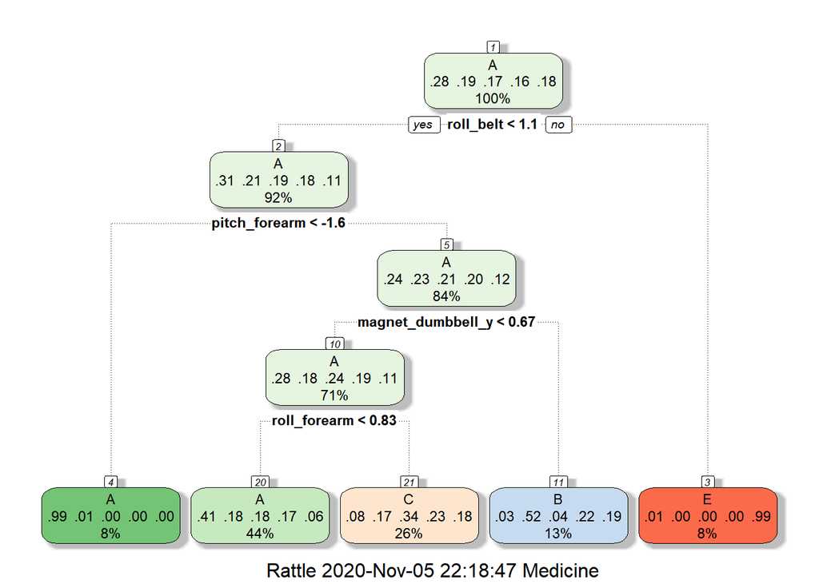

```r
fancyRpartPlot(mod_clastre$finalModel)
```

## Accuracy of the classification tree model

```r
predtree <- predict(mod_clastre, validation)
confusionMatrix(predtree, as.factor(validation$classe))
```

```
## Confusion Matrix and Statistics
##
##           Reference
## Prediction    A    B    C    D    E
##          A 1274  415  412  337  115
##          B   21  286   28  151  129
##          C   95  248  415  316  253
##          D    0    0    0    0    0
##          E    5    0    0    0  404
##
## Overall Statistics
##
##                Accuracy : 0.4851
##                  95% CI : (0.471, 0.4992)
##     No Information Rate : 0.2845
##     P-Value [Acc > NIR] : < 2.2e-16
##
##                   Kappa : 0.3271
##
##  Mcnemar's Test P-Value : NA
##
## Statistics by Class:
##
##                      Class: A Class: B Class: C Class: D Class: E
## Sensitivity            0.9133  0.30137  0.48538   0.0000  0.44839
## Specificity            0.6355  0.91681  0.77476   1.0000  0.99875
## Pos Pred Value         0.4990  0.46504  0.31274      NaN  0.98778
## Neg Pred Value         0.9485  0.84542  0.87699   0.8361  0.88943
## Prevalence             0.2845  0.19352  0.17435   0.1639  0.18373
## Detection Rate         0.2598  0.05832  0.08462   0.0000  0.08238
## Detection Prevalence   0.5206  0.12541  0.27060   0.0000  0.08340
## Balanced Accuracy      0.7744  0.60909  0.63007   0.5000  0.72357
```

The overall accuracy of the classification tree model is very poor (49%).

## Machine learning algorithm: Gradient boosting

```r
set.seed(50013)
modgbm<- train(classe~., data=training, method="gbm", verbose= FALSE)
```

## Prediction with gbm

```r
predgbm<- predict(modgbm, validation)
confusionMatrix(predgbm, as.factor(validation$classe))
```

```
## Confusion Matrix and Statistics
##
##           Reference
## Prediction    A    B    C    D    E
##          A 1380   40    0    2    0
##          B    8  882   29    4   12
##          C    5   25  810   31    8
##          D    0    1   14  761   15
##          E    2    1    2    6  866
##
## Overall Statistics
##
##                Accuracy : 0.9582
##                  95% CI : (0.9522, 0.9636)
##     No Information Rate : 0.2845
##     P-Value [Acc > NIR] : < 2.2e-16
##
##                   Kappa : 0.9471
##
##  Mcnemar's Test P-Value : 2.422e-08
##
## Statistics by Class:
##
##                      Class: A Class: B Class: C Class: D Class: E
## Sensitivity            0.9892   0.9294   0.9474   0.9465   0.9612
## Specificity            0.9880   0.9866   0.9830   0.9927   0.9973
## Pos Pred Value         0.9705   0.9433   0.9215   0.9621   0.9875
## Neg Pred Value         0.9957   0.9831   0.9888   0.9895   0.9913
## Prevalence             0.2845   0.1935   0.1743   0.1639   0.1837
## Detection Rate         0.2814   0.1799   0.1652   0.1552   0.1766
## Detection Prevalence   0.2900   0.1907   0.1792   0.1613   0.1788
## Balanced Accuracy      0.9886   0.9580   0.9652   0.9696   0.9792
```

The performance of the gradient boosting (96%) is better than classification tree.

## Machine learning algorithm - Random Forest

```r
Modrf <- train(classe ~., method='rf', data=training, ntree=100,importance=TRUE)
varImp(Modrf)
```

```
## rf variable importance
##
##   variables are sorted by maximum importance across the classes
##   only 20 most important variables shown (out of 52)
##
##                        A     B     C     D      E
## roll_belt         63.732 79.58 71.14 75.76 100.00
## pitch_forearm     46.531 61.81 97.50 61.33  46.76
## pitch_belt        24.819 96.42 48.49 37.62  33.84
## magnet_dumbbell_y 56.208 58.00 70.37 54.22  46.80
## yaw_belt          43.998 52.85 66.44 66.09  36.59
## accel_forearm_x   18.263 34.19 28.59 58.70  34.38
## magnet_dumbbell_z 51.824 41.60 56.04 40.44  47.37
## roll_forearm      39.120 29.44 36.00 27.16  26.23
## accel_dumbbell_y  30.085 27.88 38.63 25.16  28.30
## yaw_arm           34.100 21.31 23.52 22.64  13.13
## magnet_belt_y     11.105 33.92 21.89 14.80  19.86
## gyros_dumbbell_y  32.844 20.65 30.20 24.49  20.09
## gyros_belt_z      18.564 25.18 26.03 20.91  30.19
## pitch_arm          8.331 29.84 15.05 15.21  19.03
## yaw_dumbbell       8.945 29.59 15.74 14.36  18.70
## accel_dumbbell_z  20.563 23.25 15.64 23.25  28.29
## gyros_arm_y       26.726 26.29 19.72 25.20  15.65
## magnet_belt_x     13.657 26.37 24.69 13.73  17.87
## roll_dumbbell     14.026 25.19 13.04 18.59  23.98
## magnet_belt_z     15.263 21.88 18.60 25.01  18.68
```

## Prediction with random forest

```r
Predrf <- predict(Modrf, validation)
confusionMatrix(Predrf,as.factor(validation$classe))
```

```
## Confusion Matrix and Statistics
##
##           Reference
## Prediction    A    B    C    D    E
##          A 1395    8    0    0    0
##          B    0  938    2    1    0
##          C    0    3  846    7    0
##          D    0    0    7  795    5
##          E    0    0    0    1  896
##
## Overall Statistics
##
##                Accuracy : 0.9931
##                  95% CI : (0.9903, 0.9952)
##     No Information Rate : 0.2845
##     P-Value [Acc > NIR] : < 2.2e-16
##
##                   Kappa : 0.9912
##
##  Mcnemar's Test P-Value : NA
##
## Statistics by Class:
##
##                      Class: A Class: B Class: C Class: D Class: E
## Sensitivity            1.0000   0.9884   0.9895   0.9888   0.9945
## Specificity            0.9977   0.9992   0.9975   0.9971   0.9998
## Pos Pred Value         0.9943   0.9968   0.9883   0.9851   0.9989
## Neg Pred Value         1.0000   0.9972   0.9978   0.9978   0.9988
## Prevalence             0.2845   0.1935   0.1743   0.1639   0.1837
## Detection Rate         0.2845   0.1913   0.1725   0.1621   0.1827
## Detection Prevalence   0.2861   0.1919   0.1746   0.1646   0.1829
## Balanced Accuracy      0.9989   0.9938   0.9935   0.9929   0.9971
```

The overall accuracy of random forest model is very high (99.3%) which is better than gradient boosting. So, the random forest algorithm will be used to predict 20 test cases.

## Final Prediction using Randon Forest with test data

As mentioned earlier, the test data contains 20 rows without the outcome variable [classe]. The trained random forest model will be run on the test data to get predictions for the classe variables

```r
# New testing data with imputed missing values
imputed_testdat <- predict(Obj_imputed, testing)
testpred <- predict(Modrf, newdata = imputed_testdat)
testpred
```

```
##  [1] B A B A A E D B A A B C B A E E A B B B
## Levels: A B C D E
```